# CITS4009 - Project 1

Joo Kai Tay (22489437)

2023-08-07

# 1 Introduction

The data set analyzed can be obtained from the Kaggle platform. https://www.kaggle.com/datasets/nelgiriyewithana/global-youtube-statistics-2023

This data set contains information about 995 of the most subscribed YouTube channels in the world. The data set includes variables such as subscriber count, video views, upload frequency, country of origin and earnings.

## 1.1 Variable Description

- **rank**: Position of the YouTube channel based on the number of subscribers
- **Youtuber**: Name of the YouTube channel
- **subscribers**: Number of subscribers to the channel
- **video views**: Total views across all videos on the channel
- **category**: Category or niche of the channel
- **Title**: Title of the YouTube channel
- **uploads**: Total number of videos uploaded on the channel
- **Country**: Country where the YouTube channel originates
- **Abbreviation**: Abbreviation of the country
- **channel_type**: Type of the YouTube channel (e.g., individual, brand)
- **video_views_rank**: Ranking of the channel based on total video views
- **country_rank**: Ranking of the channel based on the number of subscribers within its country
- **channel_type_rank**: Ranking of the channel based on its type (individual or brand)
- **video_views_for_the_last_30_days**: Total video views in the last 30 days
- **lowest_monthly_earnings**: Lowest estimated monthly earnings from the channel
- **highest_monthly_earnings**: Highest estimated monthly earnings from the channel
- **lowest_yearly_earnings**: Lowest estimated yearly earnings from the channel
- **highest_yearly_earnings**: Highest estimated yearly earnings from the channel
- **subscribers_for_last_30_days**: Number of new subscribers gained in the last 30 days
- **created_year**: Year when the YouTube channel was created
- **created_month**: Month when the YouTube channel was created
- **created_date**: Exact date of the YouTube channel’s creation
- **Gross tertiary education enrollment (%)**: Percentage of the population enrolled in tertiary education in the country
- **Population**: Total population of the country
- **Unemployment rate**: Unemployment rate in the country
- **Urban_population**: Percentage of the population living in urban areas
- **Latitude**: Latitude coordinate of the country’s location
- **Longitude**: Longitude coordinate of the country’s location

# 2 Data loading, overview and set up

Load libraries

```r
library(ggplot2)
library(gridExtra)
library(dplyr)
library(ggthemes)
library(dplyr)
library(reshape2)
library(ca)
library(shiny)
library(knitr)
library(shinyWidgets)
library(hexbin)
library(tidyverse)
library(ggrepel)
```

*Loading the data:*

```r
path <- './data/youtube_UTF_8.csv'
youtube <- read.csv(path)
```

# 3 Using R functions to explore the data

```r
str(youtube)
```

```
## 'data.frame':    995 obs. of  28 variables:
##  $ rank                                   : int  1 2 3 4 5 6 7 8 9 10 ...
##  $ Youtuber                               : chr  "T-Series" "YouTube Movies" "MrBeast" "Cocomelon - Nursery Rhymes" ...
##  $ subscribers                            : int  245000000 170000000 166000000 162000000 159000000 119000000 112000000 111000000 106000000 98900000 ...
##  $ video.views                            : num  2.28e+11 0.00 2.84e+10 1.64e+11 1.48e+11 ...
##  $ category                               : chr  "Music" "Film & Animation" "Entertainment" "Education" ...
##  $ Title                                  : chr  "T-Series" "youtubemovies" "MrBeast" "Cocomelon - Nursery Rhymes" ...
##  $ uploads                                : int  20082 1 741 966 116536 0 1111 4716 493 574 ...
##  $ Country                                : chr  "India" "United States" "United States" "United States" ...
##  $ Abbreviation                           : chr  "IN" "US" "US" "US" ...
##  $ channel_type                           : chr  "Music" "Games" "Entertainment" "Education" ...
##  $ video_views_rank                       : int  1 4055159 48 2 3 4057944 5 44 630 8 ...
##  $ country_rank                           : num  1 7670 1 2 2 NaN 3 1 5 5 ...
##  $ channel_type_rank                      : num  1 7423 1 1 2 ...
##  $ video_views_for_the_last_30_days       : num  2.26e+09 1.20e+01 1.35e+09 1.98e+09 1.82e+09 ...
##  $ lowest_monthly_earnings                : num  564600 0 337000 493800 455900 ...
##  $ highest_monthly_earnings               : num  9.0e+06 5.0e-02 5.4e+06 7.9e+06 7.3e+06 ...
##  $ lowest_yearly_earnings                 : num  6.8e+06 4.0e-02 4.0e+06 5.9e+06 5.5e+06 ...
##  $ highest_yearly_earnings                : num  1.08e+08 5.80e-01 6.47e+07 9.48e+07 8.75e+07 ...
##  $ subscribers_for_last_30_days           : num  2e+06 NaN 8e+06 1e+06 1e+06 NaN NaN NaN 1e+05 6e+05 ...
##  $ created_year                           : num  2006 2006 2012 2006 2006 ...
##  $ created_month                          : chr  "Mar" "Mar" "Feb" "Sep" ...
##  $ created_date                           : num  13 5 20 1 20 24 12 29 14 23 ...
##  $ Gross.tertiary.education.enrollment....: num  28.1 88.2 88.2 88.2 28.1 NaN 88.2 63.2 81.9 88.2 ...
##  $ Population                             : num  1.37e+09 3.28e+08 3.28e+08 3.28e+08 1.37e+09 ...
##  $ Unemployment.rate                      : num  5.36 14.7 14.7 14.7 5.36 NaN 14.7 2.29 4.59 14.7 ...
##  $ Urban_population                       : num  4.71e+08 2.71e+08 2.71e+08 2.71e+08 4.71e+08 ...
##  $ Latitude                               : num  20.6 37.1 37.1 37.1 20.6 ...
##  $ Longitude                              : num  79 -95.7 -95.7 -95.7 79 ...
```

There are 995 observations of 28 variables, composed of 17 numerical, 7 character and 4 integer variables. It is of note that there are a number of overlapping variables in this data set, namely “Youtuber” and “Title”, “category” and “channel_type” and “Country” and “Abbreviation”. These variables will need to be inspected to find out if there are any notable differences between them.

The country rank variable also has a NaN value in it, we will need to explore the data to determine if this appears in any of the other geographical variables.

## 3.1 Analyzing the data using summary()

```r
summary(youtube)
```

```
##       rank         Youtuber          subscribers         video.views
##  Min.   :  1.0   Length:995         Min.   : 12300000   Min.   :0.000e+00
##  1st Qu.:249.5   Class :character   1st Qu.: 14500000   1st Qu.:4.288e+09
##  Median :498.0   Mode  :character   Median : 17700000   Median :7.761e+09
##  Mean   :498.0                      Mean   : 22982412   Mean   :1.104e+10
##  3rd Qu.:746.5                      3rd Qu.: 24600000   3rd Qu.:1.355e+10
##  Max.   :995.0                      Max.   :245000000   Max.   :2.280e+11
##
##    category            Title              uploads           Country
##  Length:995         Length:995         Min.   :     0.0   Length:995
##  Class :character   Class :character   1st Qu.:   194.5   Class :character
##  Mode  :character   Mode  :character   Median :   729.0   Mode  :character
##                                        Mean   :  9187.1
##                                        3rd Qu.:  2667.5
##                                        Max.   :301308.0
##
##  Abbreviation       channel_type       video_views_rank   country_rank
##  Length:995         Length:995         Min.   :      1   Min.   :   1.0
##  Class :character   Class :character   1st Qu.:    323   1st Qu.:  11.0
##  Mode  :character   Mode  :character   Median :    916   Median :  51.0
##                                        Mean   : 554249   Mean   : 386.1
##                                        3rd Qu.:   3584   3rd Qu.: 123.0
##                                        Max.   :4057944   Max.   :7741.0
##                                        NA's   :1         NA's   :116
##  channel_type_rank video_views_for_the_last_30_days lowest_monthly_earnings
##  Min.   :   1.0    Min.   :1.000e+00                Min.   :     0
##  1st Qu.:  27.0    1st Qu.:2.014e+07                1st Qu.:  2700
##  Median :  65.5    Median :6.408e+07                Median : 13300
##  Mean   : 745.7    Mean   :1.756e+08                Mean   : 36886
##  3rd Qu.: 139.8    3rd Qu.:1.688e+08                3rd Qu.: 37900
##  Max.   :7741.0    Max.   :6.589e+09                Max.   :850900
##  NA's   :33        NA's   :56
##  highest_monthly_earnings lowest_yearly_earnings highest_yearly_earnings
##  Min.   :       0         Min.   :       0       Min.   :        0
##  1st Qu.:   43500         1st Qu.:   32650       1st Qu.:   521750
##  Median :  212700         Median :  159500       Median :  2600000
##  Mean   :  589808         Mean   :  442257       Mean   :  7081814
##  3rd Qu.:  606800         3rd Qu.:  455100       3rd Qu.:  7300000
##  Max.   :13600000         Max.   :10200000       Max.   :163400000
##
```

[output cut: 9 more lines]

```
##  Min.   :  7.60                          Min.   :2.025e+05   Min.   : 0.750
##  1st Qu.: 36.30                          1st Qu.:8.336e+07   1st Qu.: 5.270
##  Median : 68.00                          Median :3.282e+08   Median : 9.365
##  Mean   : 63.63                          Mean   :4.304e+08   Mean   : 9.279
##  3rd Qu.: 88.20                          3rd Qu.:3.282e+08   3rd Qu.:14.700
##  Max.   :113.10                          Max.   :1.398e+09   Max.   :14.720
##  NA's   :123                             NA's   :123         NA's   :123
##  Urban_population       Latitude        Longitude
##  Min.   :    35588   Min.   :-38.42   Min.   :-172.10
##  1st Qu.: 55908316   1st Qu.: 20.59   1st Qu.: -95.71
##  Median :270663028   Median : 37.09   Median : -51.93
##  Mean   :224214982   Mean   : 26.63   Mean   : -14.13
##  3rd Qu.:270663028   3rd Qu.: 37.09   3rd Qu.:  78.96
##  Max.   :842933962   Max.   : 61.92   Max.   : 138.25
##  NA's   :123         NA's   :123      NA's   :123
```

The `created_year` variable has a minimum of 1970 which is likely to be erroneous as YouTube was created in 2005. The following code displays all values that are less than 2005:

```r
filtered_rows <- youtube[(!is.na(youtube$created_year) & youtube$created_year < 2005), ]
filtered_rows
```

```
##     rank Youtuber subscribers video.views        category   Title uploads
## 102  102  YouTube    36300000  3010784935 News & Politics YouTube     744
##           Country Abbreviation  channel_type video_views_rank country_rank
## 102 United States           US Entertainment             2860           32
##     channel_type_rank video_views_for_the_last_30_days lowest_monthly_earnings
## 102                 5                         21103000                    5300
##     highest_monthly_earnings lowest_yearly_earnings highest_yearly_earnings
## 102                    84400                  63300                   1e+06
##     subscribers_for_last_30_days created_year created_month created_date
## 102                        3e+05         1970           Jan            1
##     Gross.tertiary.education.enrollment.... Population Unemployment.rate
## 102                                    88.2  328239523              14.7
##     Urban_population Latitude Longitude
## 102        270663028 37.09024 -95.71289
```

## 3.2 Analyzing the data using head()

```r
head(youtube)
```

```
##   rank                   Youtuber subscribers  video.views         category
## 1    1                   T-Series   245000000 228000000000            Music
## 2    2             YouTube Movies   170000000            0 Film & Animation
## 3    3                    MrBeast   166000000  28368841870    Entertainment
## 4    4 Cocomelon - Nursery Rhymes   162000000 164000000000        Education
## 5    5                  SET India   159000000 148000000000            Shows
## 6    6                      Music   119000000            0              nan
##                        Title uploads       Country Abbreviation  channel_type
## 1                   T-Series   20082         India           IN         Music
## 2              youtubemovies       1 United States           US         Games
## 3                    MrBeast     741 United States           US Entertainment
## 4 Cocomelon - Nursery Rhymes     966 United States           US     Education
## 5                  SET India  116536         India           IN Entertainment
## 6                      Music       0           nan          nan         Music
##   video_views_rank country_rank channel_type_rank
```

[output cut: 41 more lines]

Upon inspection of the first 6 rows of data, another issue stands out. For certain variables such as `category`, `country` and `Abbreviation`, `nan` is used to represent missing data. However, these values will not be picked up by the `is.na()` function that R offers, which only recognized `NaN` or `NA`. We will need to transform these values to get a full understanding of the missing values in the data set.

## 3.3 NA Values in the dataset

The following is the count of NA values in each column of the data set. The function has been modified to use both the in-built function `is.na()` as well as to account for any values which have the value `nan`.

```
##                                category                                 Country
##                                      46                                     122
##                            Abbreviation                            channel_type
##                                     122                                      30
##                        video_views_rank                            country_rank
##                                       1                                     116
##                       channel_type_rank        video_views_for_the_last_30_days
##                                      33                                      56
##            subscribers_for_last_30_days                            created_year
##                                     337                                       5
##                           created_month                            created_date
##                                       5                                       5
## Gross.tertiary.education.enrollment....                              Population
##                                     123                                     123
##                       Unemployment.rate                        Urban_population
##                                     123                                     123
##                                Latitude                               Longitude
##                                     123                                     123
```

### 3.3.1 Geographical Variables

From the previous table, it can be seen that there are 123 observations missing for each of the geographical variables. The same observations are all missing the geographical and demographic information.

```r
summary(youtube[is.na(youtube$Population), c("Unemployment.rate", "Urban_population", "Latitude", "Longitude", "Gross.tertiary.education.enrollment....")])
```

```
##  Unemployment.rate Urban_population    Latitude     Longitude
##  Min.   : NA       Min.   : NA      Min.   : NA   Min.   : NA
##  1st Qu.: NA       1st Qu.: NA      1st Qu.: NA   1st Qu.: NA
##  Median : NA       Median : NA      Median : NA   Median : NA
##  Mean   :NaN       Mean   :NaN      Mean   :NaN   Mean   :NaN
##  3rd Qu.: NA       3rd Qu.: NA      3rd Qu.: NA   3rd Qu.: NA
##  Max.   : NA       Max.   : NA      Max.   : NA   Max.   : NA
##  NA's   :123       NA's   :123      NA's   :123   NA's   :123
##  Gross.tertiary.education.enrollment....
##  Min.   : NA
##  1st Qu.: NA
##  Median : NA
##  Mean   :NaN
##  3rd Qu.: NA
##  Max.   : NA
##  NA's   :123
```

## 3.4 Unique values in categorical variables

Upon examining the unique levels in the categorical variables, some questions arise: - There are 19 categories but 15 channel types, we will examine them to see the differences - There are 995 Youtubers but only 992 unique channel titles, have some of the channels been recorded twice? - There are 13 months

```r
non_numeric_cols <- youtube %>%
  select_if(~ !is.numeric(.)) %>%
  colnames()

unique_value_counts <- youtube %>%
  select(all_of(non_numeric_cols)) %>%
  summarise(across(everything(), ~ n_distinct(.)))

unique_value_counts
```

```
##   Youtuber category Title Country Abbreviation channel_type created_month
## 1      995       19   992      50           50           15            13
```

### 3.4.1 Displaying the unique values in months

The 13th value that we saw in the created_months column turns out to be `nan` which was recognized as a unique value as it did not follow the R convention to use `NaN` or `NA`.

```r
unique_months <- unique(youtube$created_month)
unique_months
```

```
##  [1] "Mar" "Feb" "Sep" "May" "Apr" "Jan" "Dec" "Jun" "Aug" "Jul" "Oct" "Nov"
## [13] "nan"
```

# 4 Visualisation

## 4.1 Channel counts by country

The following chart shows the top 10 Countries in Youtube by number of channels. The United States had the most number of channels at 31.46%, followed by India at 16.88%. The `nan` values show up again with 12.26% of observation having a missing value in this category.

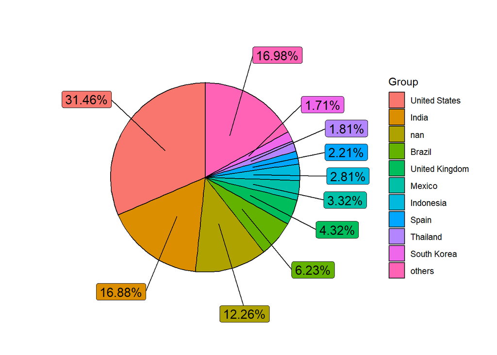

Another way of displaying number of channels by country is show on the map below. Larger circles indicate the presence of more channels in the country. From this plot, we can see at least one instance of erroneous data where a channel is plotted in the middle of the ocean on the left of the map.

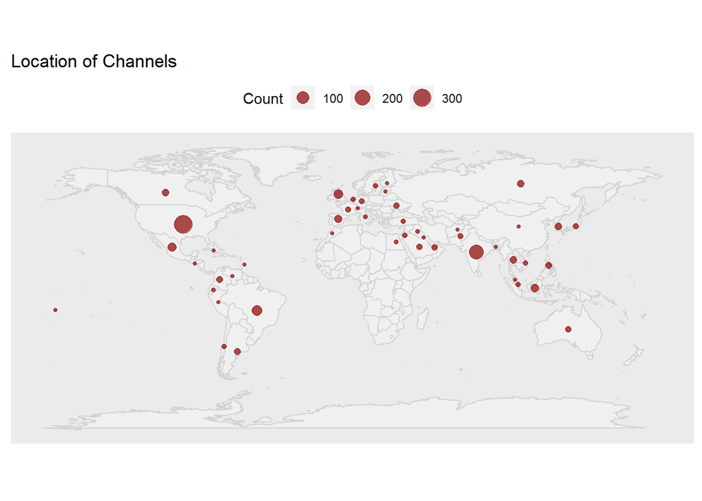

## 4.2 Category Analysis

There are two variables used to represent type of channel in the YouTube data set, `channel_type` and `category`. The following filled bar chart shows how the two descriptors differ.

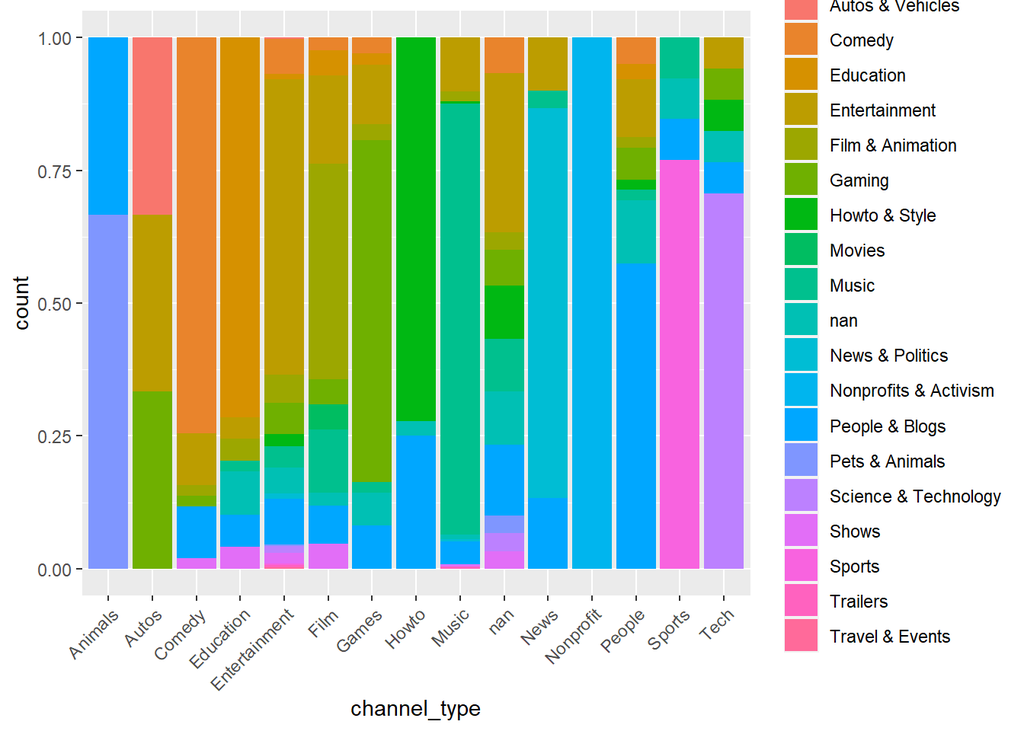

```r
ggplot(youtube) +
geom_bar(aes(x=channel_type, fill = category), position="fill") +
theme(axis.text.x = element_text(angle = 45, hjust = 1))
```

### 4.2.1 Created Year

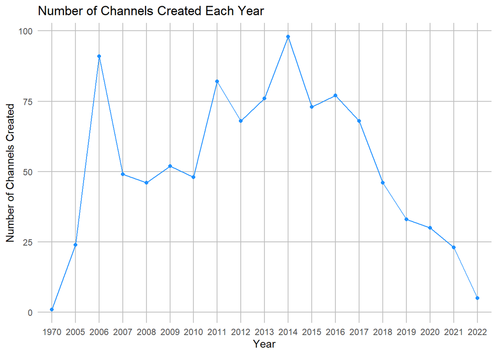

Now that we have seen the general trend of channels created, let us explore it by category.The plot below shows the cumulative subscriber count for each category from 2005 - 2022.

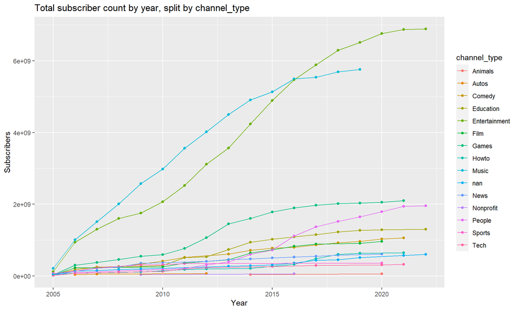

Due to the large values in Entertainment and Music, the other channel types are not being displayed well. Facet wrap is used to display each category individually with it’s own scale to allow easier visulization of trends over the years. Some trends can be observed:

- Comedy, Entertainment, News and Music have grown steadily year over year
- Growth in Sports have plateaued following a sharp increase in 2010
- Animals, Nonprofit and Autos are not very popular channel types, with no growth in recent years

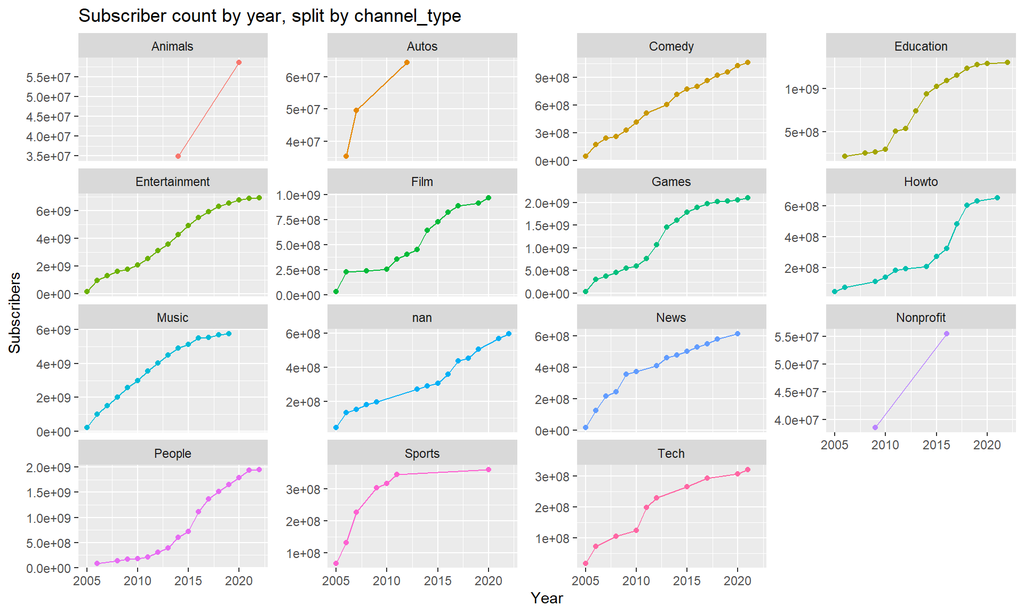

## 4.3 Investigating Income

In this section, we investigate the vairables that influence the earning potential of YouTubers. The plot does not show any strong correlation between `subscribers` and `video.views` with `highest_yearly_earnings`. However, The presence of outliers greats limits the visualization of the data.

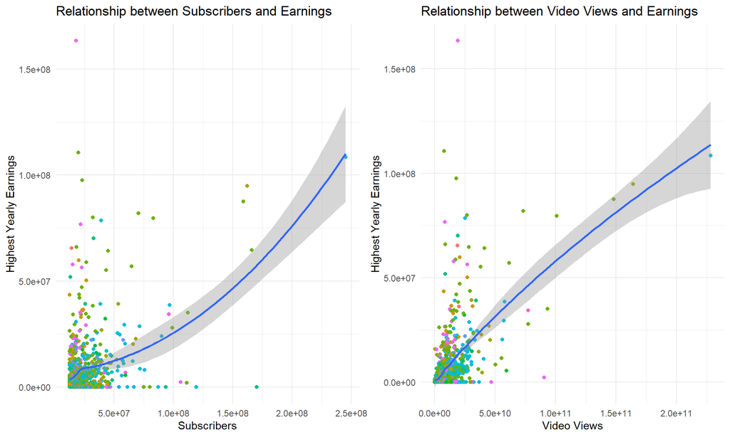

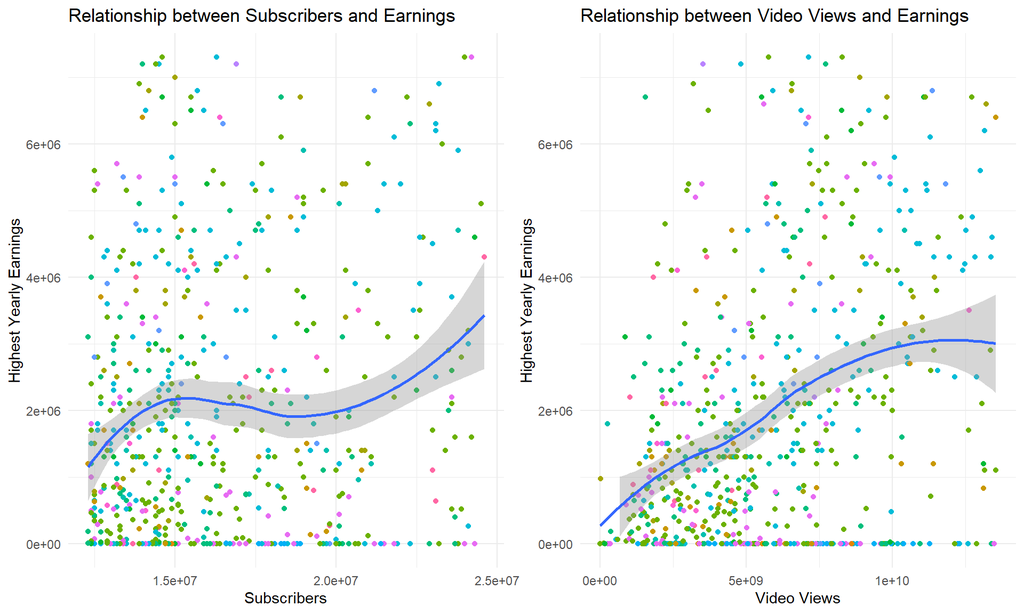